# COVID-19 HOSPITALIZATIONS TIME SERIES

```r
library(dplyr)
library(lubridate)
library(ggplot2)
library(tswge)
library(reshape2)
library(mice)
library(cowplot)
library(vars)
library(nnfor)
library(caret)
library(vctrs)
library(rlang)
library(modeltime.ensemble)
```

# DATA CLEANING

### Healthcare.gov dataset

```r
#Read in data and view data

covid = read.csv("D:/MS in Data Science/1 Datasets/Sem 5/Covid_Cases_Timeseries.csv", header = T)

dim(covid)
```

```
## [1] 40618   117
```

```r
#Filter to only Texas
txcovidvars <- covid[which(covid$state == 'TX'),]
dim(txcovidvars)
```

```
## [1] 818 117
```

```r
#Narrow down variables to look at
#Date, total #of inpatient beds, #of IP beds in use, % of IP beds in use
#of beds used by covid, %of beds used by covid patients, and covid deaths

txcovid <- txcovidvars[c("date", "inpatient_beds", "inpatient_beds_used", "inpatient_beds_utilization", "inpatient_beds_used_covid", "percent_of_inpatients_with_covid", "deaths_covid")]
```

```r
#Change date-time format and order by date
txcovid$date<-as.Date(txcovid$date)
txcovid <- txcovid[order(txcovid$date),]

summary(txcovid)
```

```
##       date            inpatient_beds   inpatient_beds_used
##  Min.   :2020-01-01   Min.   :    28   Min.   :   21
##  1st Qu.:2020-07-23   1st Qu.: 56674   1st Qu.:38484
##  Median :2021-02-12   Median : 66075   Median :48178
##  Mean   :2021-02-12   Mean   : 57095   Mean   :41125
##  3rd Qu.:2021-09-04   3rd Qu.: 68642   3rd Qu.:51135
##  Max.   :2022-03-28   Max.   :108966   Max.   :56943
##
##  inpatient_beds_utilization inpatient_beds_used_covid
##  Min.   :0.4829             Min.   :    0
##  1st Qu.:0.6948             1st Qu.: 2409
##  Median :0.7282             Median : 4276
##  Mean   :0.7182             Mean   : 5769
##  3rd Qu.:0.7592             3rd Qu.: 9170
##  Max.   :0.9394             Max.   :14917
##
##  percent_of_inpatients_with_covid  deaths_covid
##  Min.   :0.0000                   Min.   :  0.00
##  1st Qu.:0.0701                   1st Qu.: 23.00
##  Median :0.1004                   Median : 51.00
##  Mean   :0.1264                   Mean   : 76.91
##  3rd Qu.:0.1883                   3rd Qu.:126.50
##  Max.   :0.3118                   Max.   :297.00
##                                   NA's   :11
```

```r
which(is.na(txcovid$deaths_covid))
```

```
##  [1] 36 37 38 39 40 41 42 43 44 45 46
```

```r
#double check NAs are gone
which(is.na(txcovid$deaths_covid))
```

[output not shown]

```
## integer(0)
```

# DATA CLEANING

### CDC Covid Vaccinations Dataset

```r
#Read in vaccination data from the CDC found here: https://github.com/owid/covid-19-data/tree/master/public/data/vaccinations#united-states-vaccination-data

vaccine = read.csv("D:/MS in Data Science/1 Datasets/Sem 5/us_state_vaccinations_timeseries.csv", header = T)
```

```r
#Filter to only Texas
txvaxvars <- vaccine[which(vaccine$location == 'Texas'),]
dim(txvaxvars)
```

```
## [1] 441  16
```

```r
#Narrow down variables
txvax <- txvaxvars[c("date", "daily_vaccinations")]
```

```r
#Change date-time format to match other data set
txvax$date <-as.Date(txvax$date)
```

```r
summary(txvax)
```

```
##       date            daily_vaccinations
##  Min.   :2021-01-12   Min.   : 21842
##  1st Qu.:2021-05-02   1st Qu.: 65834
##  Median :2021-08-20   Median : 86837
##  Mean   :2021-08-20   Mean   :100887
##  3rd Qu.:2021-12-08   3rd Qu.:119601
##  Max.   :2022-03-28   Max.   :307347
##                       NA's   :1
```

### Merge Datasets

```r
### MERGE DATASETS
txdata <- left_join(txcovid, txvax, by = "date")
```

```r
#Remove pre-vaccine data - will start Feb 2021 to make sure all variables are the same length of time.
txdata <- subset(txdata, date >= "2021-02-01")
```

```r
summary(txdata)
```

```
##       date            inpatient_beds  inpatient_beds_used
##  Min.   :2021-02-01   Min.   :57032   Min.   :41069
##  1st Qu.:2021-05-17   1st Qu.:65342   1st Qu.:47872
##  Median :2021-08-30   Median :67514   Median :49988
##  Mean   :2021-08-30   Mean   :66517   Mean   :49778
##  3rd Qu.:2021-12-13   3rd Qu.:68851   3rd Qu.:51854
##  Max.   :2022-03-28   Max.   :73586   Max.   :56287
##  inpatient_beds_utilization inpatient_beds_used_covid
##  Min.   :0.6573             Min.   : 1544
##  1st Qu.:0.7215             1st Qu.: 3240
##  Median :0.7515             Median : 4213
##  Mean   :0.7489             Mean   : 6196
##  3rd Qu.:0.7773             3rd Qu.: 9227
##  Max.   :0.8265             Max.   :14743
##  percent_of_inpatients_with_covid  deaths_covid    daily_vaccinations
##  Min.   :0.03311                  Min.   :  8.00   Min.   : 21842
##  1st Qu.:0.06559                  1st Qu.: 31.00   1st Qu.: 64934
##  Median :0.08862                  Median : 51.00   Median : 87585
##  Mean   :0.12387                  Mean   : 79.91   Mean   :102078
##  3rd Qu.:0.18050                  3rd Qu.:126.00   3rd Qu.:121414
##  Max.   :0.30267                  Max.   :262.00   Max.   :307347
```

From the above summary, we can see the date range is correct - Feb 2021 through March 2022.There are no NAs or missing values entered as 0s. Interestingly, inpatient bed utilization ranges from 65% to 82%. There were reports of IP beds running out, and that may be true from a practical hospital by hospital basis, but at the state level this doesn’t look to be the case. Covid hospitalizations take up about 12% of those beds on average, but got as high as 30% at one point.

# EXPLORITORY DATA ANALYSIS

### Total Beds Used for Inpatient Hospitalizations

```r
#Plot the realizations of the variables of interest
#Originally planned to use Covid Deaths as well, but the data mirrored covid beds used so I chose not to.
txeda <- txdata[c("date", "inpatient_beds", "inpatient_beds_used", "inpatient_beds_used_covid", "daily_vaccinations")]
txeda_long <- melt(txeda, id.vars = "date")
```

Total inpatient beds are more stationary than the beds used, which appear to peak in correlation with covid beds used.

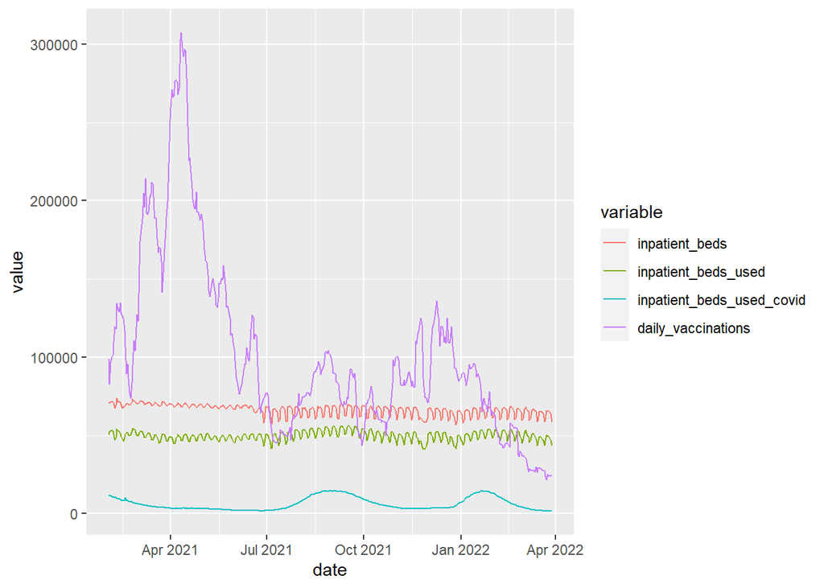

```r
options(scipen=999)
ggplot(txeda_long, aes(x = date, y = value, col = variable)) + geom_line()
```

```r
IP_Beds <- ggplot(txdata, aes(x=date, y=inpatient_beds)) + geom_line() +
  xlab("Time") + ylab("Total Inpatient Beds") + ggtitle("Total Inpatient Beds")
```

```r
IP_Beds_Used <- ggplot(txdata, aes(x=date, y=inpatient_beds_used)) + geom_line() +
  xlab("Time") + ylab("Inpatient Beds") + ggtitle("Total Inpatient Beds Used")
```

```r
Covid_IP_Beds_Used <- ggplot(txdata, aes(x=date, y=inpatient_beds_used_covid)) + geom_line() + xlab("Time") + ylab("Covid Beds") + ggtitle("Inpatient Beds Used by Covid Patients")
```

```r
Daily_Vaccinations <- ggplot(txdata, aes(x=date, y=daily_vaccinations)) + geom_line() + xlab("Time") + ylab("Daily Vaccinations") + ggtitle("Total Daily Vaccinations")
```

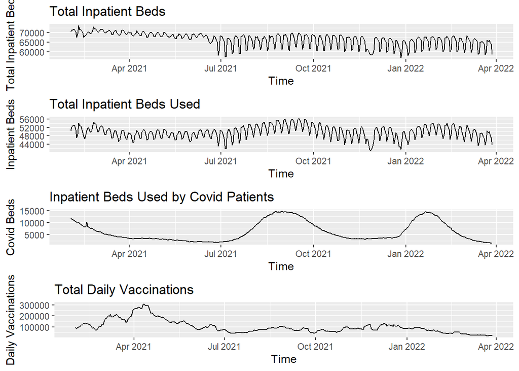

```r
plot <- ggdraw() + draw_label("Title", fontface='bold')
plot_grid(IP_Beds, IP_Beds_Used, Covid_IP_Beds_Used, Daily_Vaccinations, nrow = 4)
```

# MODEL 1

### Univariate ARMA

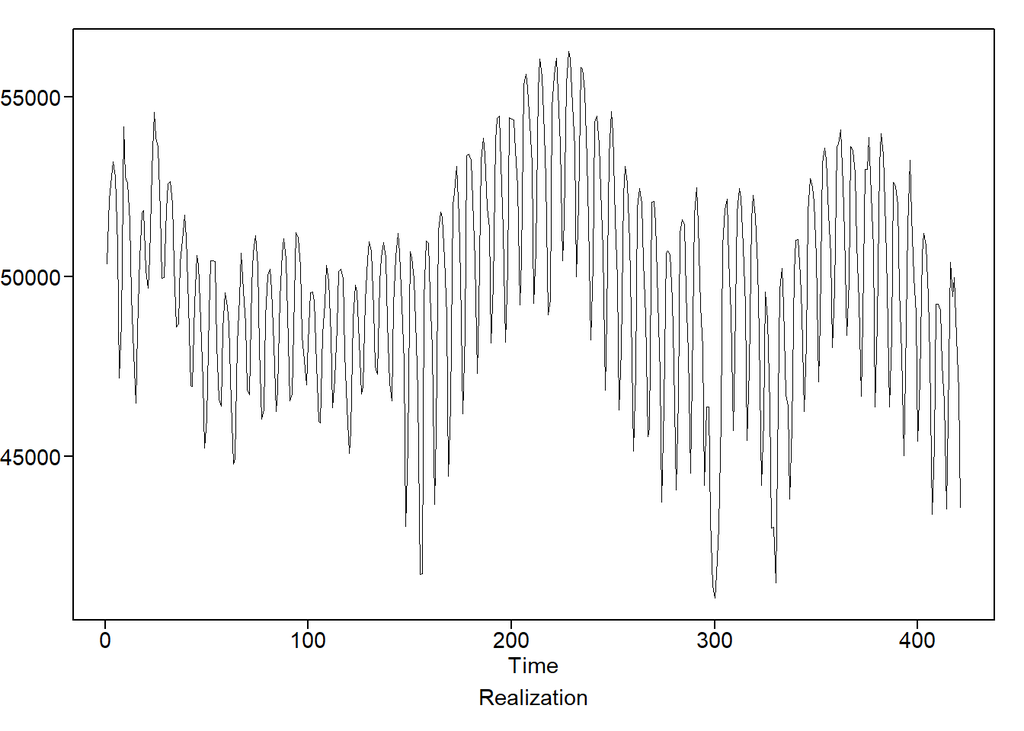

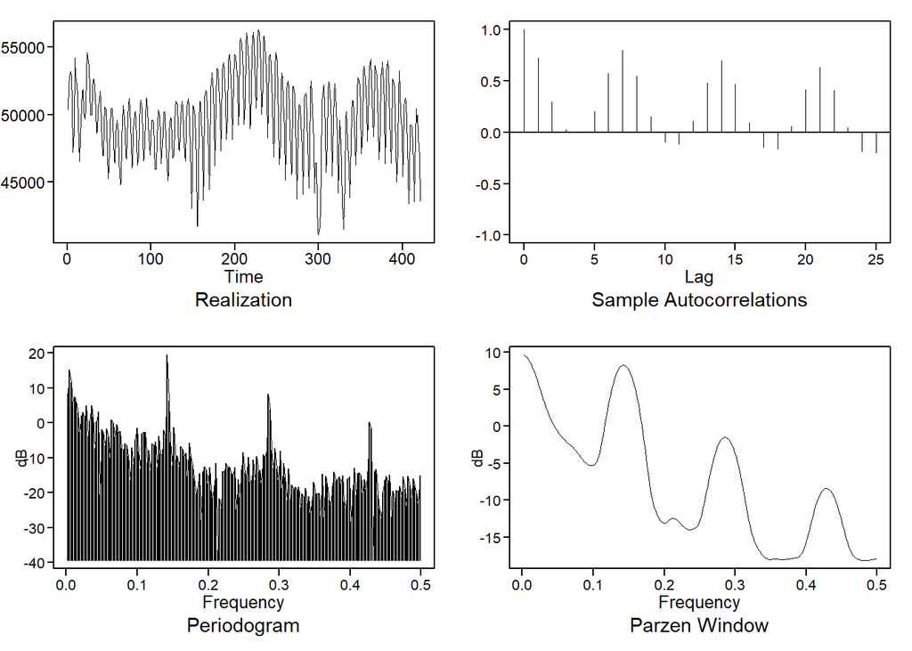

```r
plotts.wge(txdata$inpatient_beds_used)
```

Overfitting the data

```r
txdata_overfit = est.ar.wge(txdata$inpatient_beds_used, p=14)
```

```
##
## Coefficients of Original polynomial:
## 1.0426 -0.2420 0.0115 -0.0191 -0.0113 -0.0878 0.8502 -0.8349 0.1048 0.0479 -0.0207 -0.0023 0.1511 -0.0478
##
## Factor                 Roots                Abs Recip    System Freq
## 1-1.2396B+0.9862B^2    0.6285+-0.7868i      0.9931       0.1427
## 1+0.4415B+0.9701B^2   -0.2275+-0.9894i      0.9850       0.2860
## 1-0.9695B              1.0315               0.9695       0.0000
## 1+1.7071B+0.9022B^2   -0.9461+-0.4618i      0.9498       0.4277
## 1-1.6298B+0.7556B^2    1.0785+-0.4004i      0.8692       0.0566
## 1-0.2079B+0.4952B^2    0.2099+-1.4055i      0.7037       0.2264
## 1+1.1768B+0.4758B^2   -1.2367+-0.7566i      0.6898       0.4126
## 1-0.3212B              3.1131               0.3212       0.0000
##
##
##
## Coefficients of Original polynomial:
## 1.0426 -0.2420 0.0115 -0.0191 -0.0113 -0.0878 0.8502 -0.8349 0.1048 0.0479 -0.0207 -0.0023 0.1511 -0.0478
##
## Factor                 Roots                Abs Recip    System Freq
## 1-1.2396B+0.9862B^2    0.6285+-0.7868i      0.9931       0.1427
## 1+0.4415B+0.9701B^2   -0.2275+-0.9894i      0.9850       0.2860
## 1-0.9695B              1.0315               0.9695       0.0000
## 1+1.7071B+0.9022B^2   -0.9461+-0.4618i      0.9498       0.4277
## 1-1.6298B+0.7556B^2    1.0785+-0.4004i      0.8692       0.0566
## 1-0.2079B+0.4952B^2    0.2099+-1.4055i      0.7037       0.2264
## 1+1.1768B+0.4758B^2   -1.2367+-0.7566i      0.6898       0.4126
## 1-0.3212B              3.1131               0.3212       0.0000
##
##
```

```r
factor.wge(c(rep(0,6),1))
```

```
##
## Coefficients of Original polynomial:
## 0.0000 0.0000 0.0000 0.0000 0.0000 0.0000 1.0000
##
## Factor                 Roots                Abs Recip    System Freq
## 1-1.0000B              1.0000               1.0000       0.0000
## 1+0.4450B+1.0000B^2   -0.2225+-0.9749i      1.0000       0.2857
## 1-1.2470B+1.0000B^2    0.6235+-0.7818i      1.0000       0.1429
## 1+1.8019B+1.0000B^2   -0.9010+-0.4339i      1.0000       0.4286
##
##
```

Strong evidence of weekly seasonality

```r
#model out the seasonality s=7
dif = artrans.wge(txdata$inpatient_beds_used, c(rep(0,6),1))
```

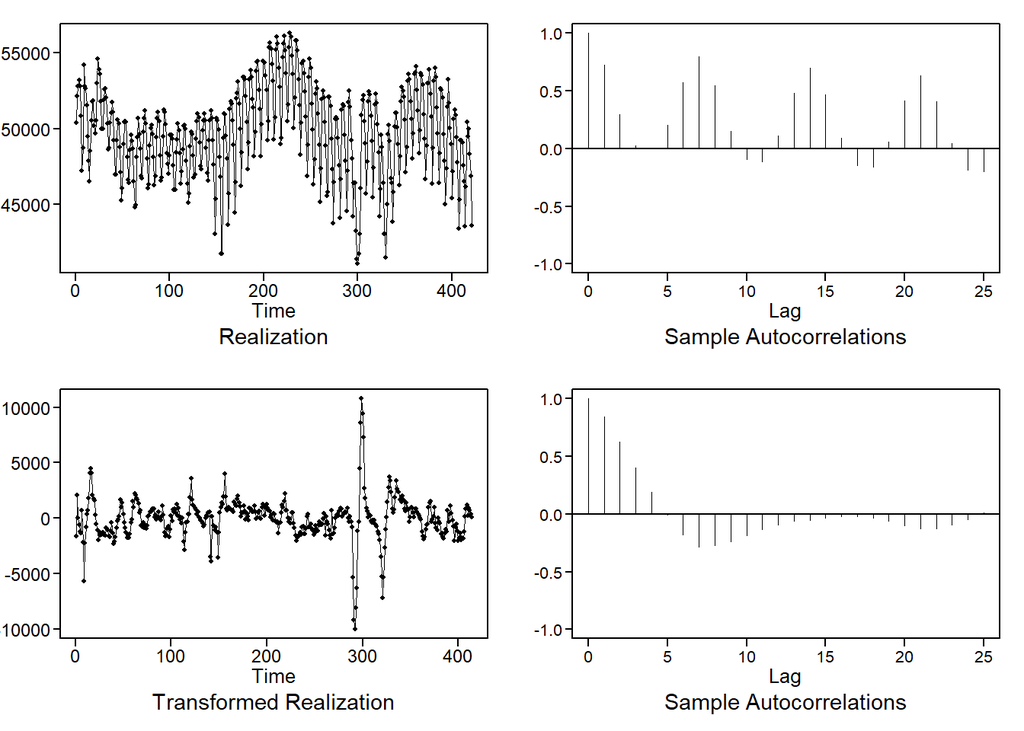

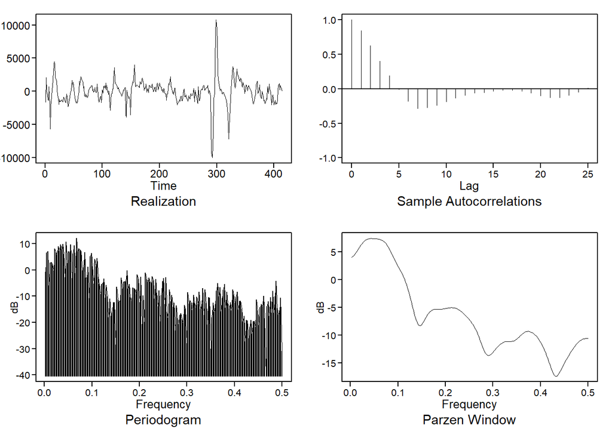

```r
plotts.sample.wge(dif)
```

Doesn’t appear to be white noise

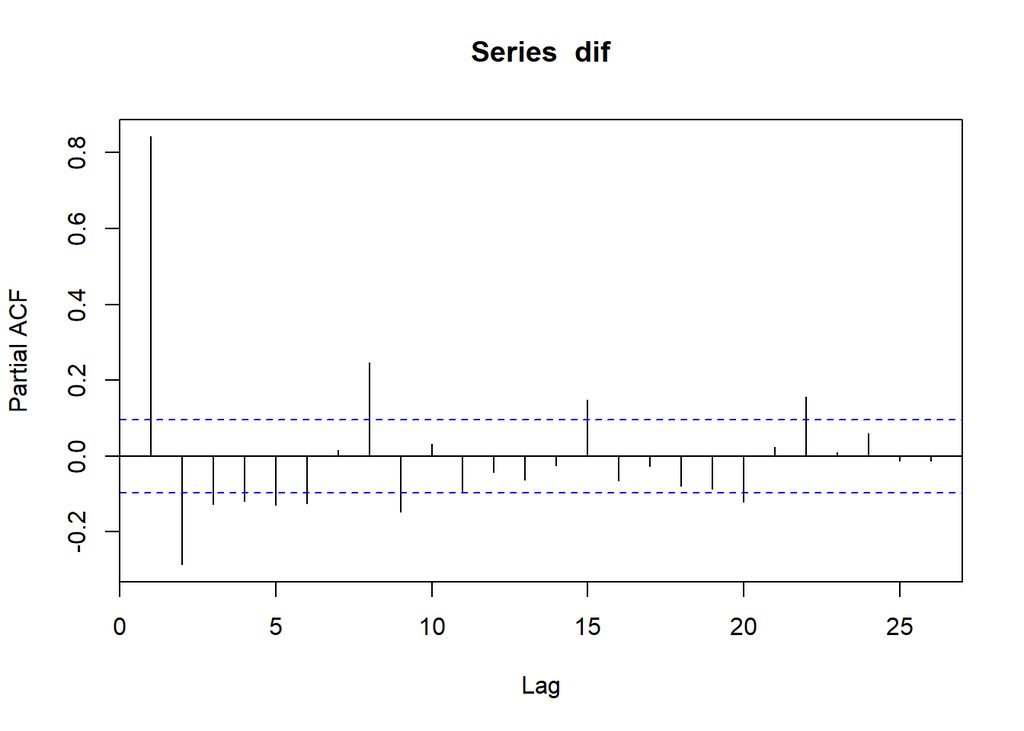

```r
pacf(dif)
```

Get models with the lowest AIC/BIC. An AR(8,1) appears on both lists.

```r
aic5.wge(dif, p=0:12, q= 0:3)
```

```
## ---------WORKING... PLEASE WAIT...
##
##
## Five Smallest Values of  aic
```

```
##       p    q        aic
## 45   11    0   13.59723
## 50   12    1   13.59751
## 34    8    1   13.59762
## 37    9    0   13.59782
## 46   11    1   13.59928
```

```r
aic5.wge(dif, p=0:12, q= 0:3, type = "bic")
```

```
## ---------WORKING... PLEASE WAIT...
##
##
## Five Smallest Values of  bic
```

```
##       p    q        bic
## 34    8    1   13.69487
## 37    9    0   13.69507
## 38    9    1   13.70784
## 35    8    2   13.70871
## 41   10    0   13.70927
```

```r
final = est.arma.wge(dif, p=8, q=1)
```

```
##
## Coefficients of Original polynomial:
## 0.5865 0.2708 -0.0841 -0.0164 0.0036 -0.0674 -0.3532 0.2932
##
## Factor                 Roots                Abs Recip    System Freq
## 1+0.9054B             -1.1044               0.9054       0.5000
## 1-1.6091B+0.7865B^2    1.0229+-0.4744i      0.8869       0.0691
## 1+1.1790B+0.7665B^2   -0.7691+-0.8445i      0.8755       0.3676
## 1-0.3244B+0.7284B^2    0.2227+-1.1504i      0.8534       0.2196
## 1-0.7374B              1.3561               0.7374       0.0000
##
##
```

### ARMA Model: Short 14-Day Forecast

```r
model1_fore_short = fore.aruma.wge(txdata$inpatient_beds_used, phi = final$phi, theta = final$theta, s = 7,  limits = T, n.ahead = 14, lastn = T)
```

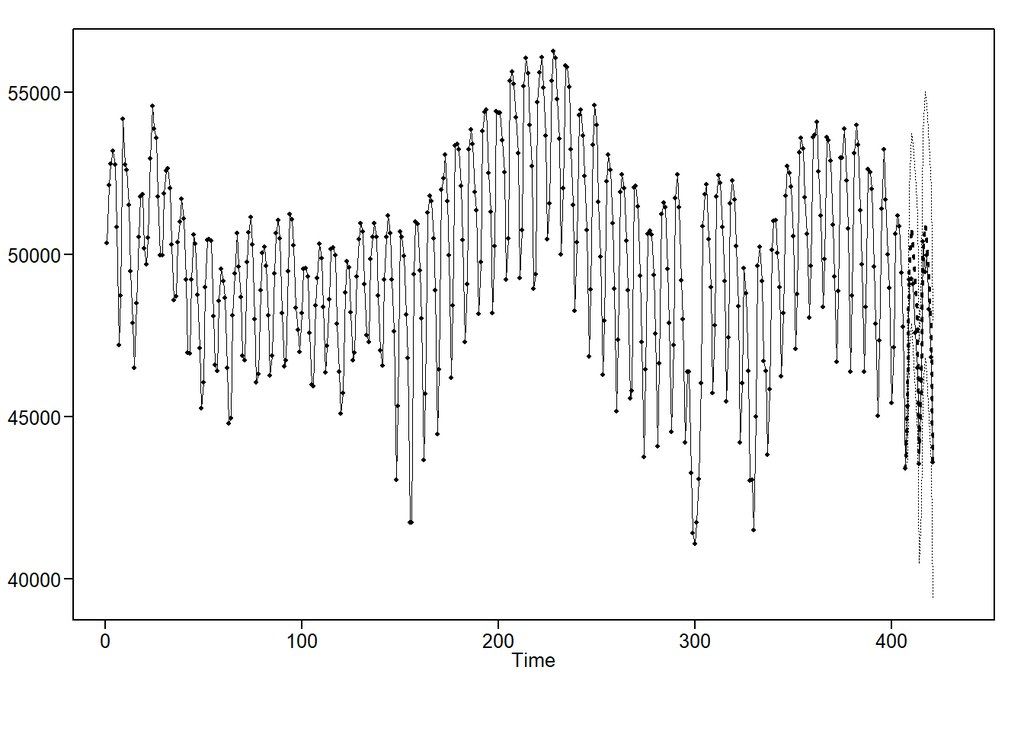

```r
model1_fore_short
```

```r
model1_ase_short = mean((txdata$inpatient_beds_used[(length(txdata$inpatient_beds_used)-13):length(txdata$inpatient_beds_used)]- model1_fore_short$f)^2)
model1_ase_short
```

```
## [1] 903925.5
```

### ARMA Model: Long 90-Day Forecast

```r
model1_fore_long = fore.aruma.wge(txdata$inpatient_beds_used, phi = final$phi, theta = final$theta, s = 7,  limits = T, n.ahead = 90, lastn = T)
```

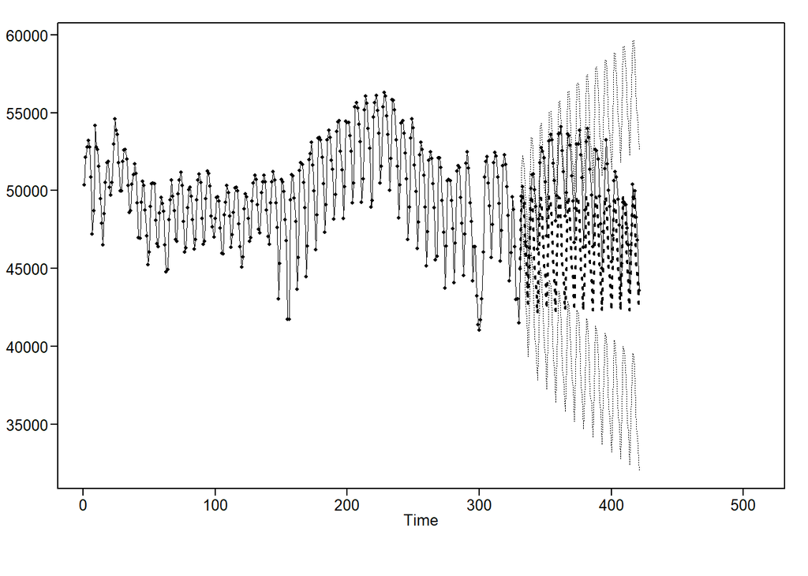

```r
model1_fore_long
```

```r
model1_ase_long = mean((txdata$inpatient_beds_used[(length(txdata$inpatient_beds_used)-89):length(txdata$inpatient_beds_used)]- model1_fore_long$f)^2)
model1_ase_long
```

```
## [1] 15714547
```

# MODEL 2

### Univariate ARIMA Model

This model removes an additional 1-B factor.

```r
#model out the seasonality 1-B factor
dif2 = artrans.wge(dif,1)
```

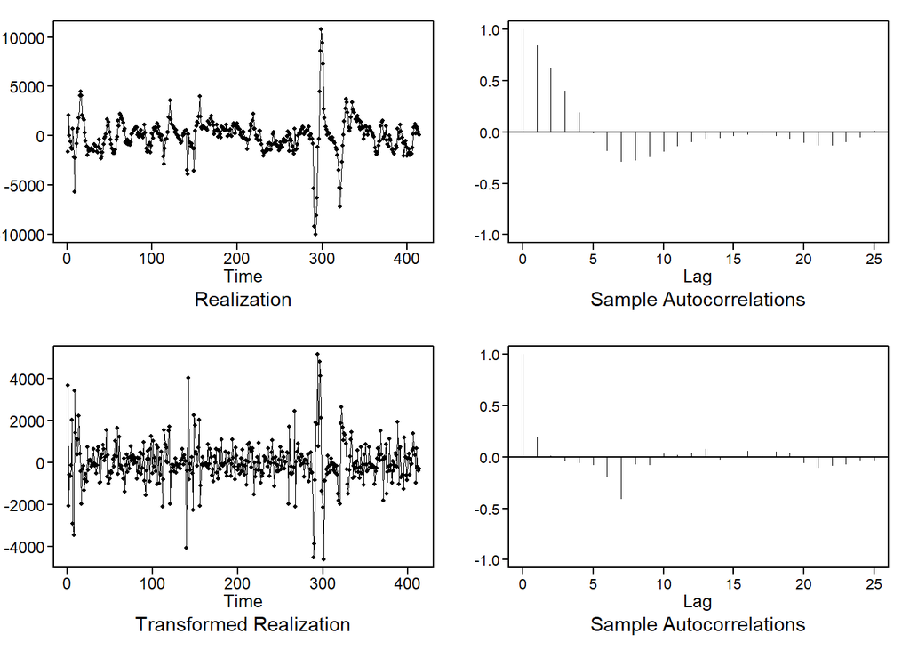

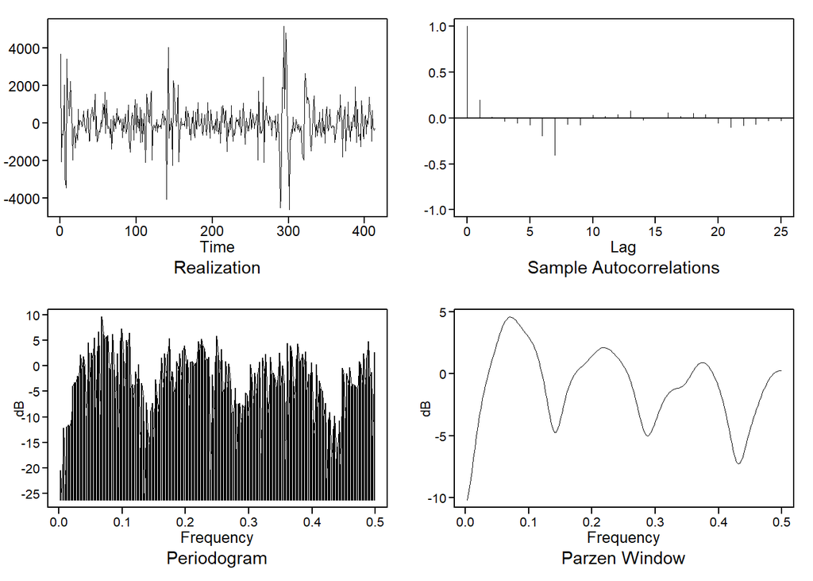

```r
plotts.sample.wge(dif2)
```

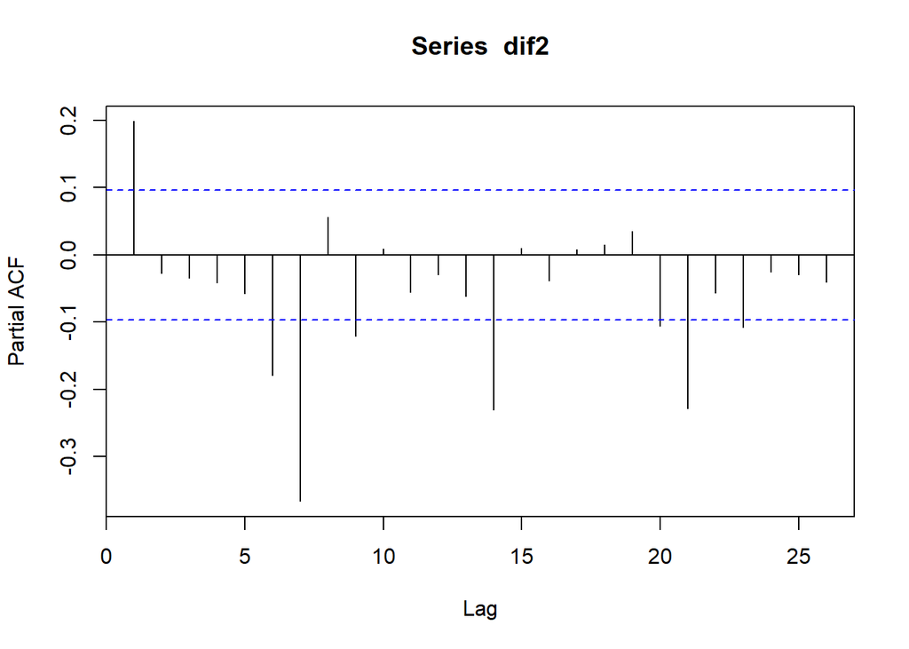

```r
pacf(dif2)
```

Get models with the lowest AIC/BIC. An AR(7,1) appears on both lists.

```r
aic5.wge(dif2, p=0:12, q= 0:3)
```

```
## ---------WORKING... PLEASE WAIT...
##
##
## Five Smallest Values of  aic
```

```
##       p    q        aic
## 37    9    0   13.68565
## 30    7    1   13.68717
## 34    8    1   13.68985
## 41   10    0   13.69040
## 45   11    0   13.69191
```

```r
aic5.wge(dif2, p=0:12, q= 0:3, type = "bic")
```

```
## ---------WORKING... PLEASE WAIT...
##
##
## Five Smallest Values of  bic
```

```
##       p    q        bic
## 29    7    0   13.77166
## 30    7    1   13.77485
## 33    8    0   13.78012
## 37    9    0   13.78307
## 34    8    1   13.78727
```

```r
final2 = est.arma.wge(dif2, p=7, q=1)
```

```
##
## Coefficients of Original polynomial:
## -0.1483 0.0028 -0.0471 -0.0552 -0.0409 -0.1011 -0.4335
##
## Factor                 Roots                Abs Recip    System Freq
## 1-1.5806B+0.8069B^2    0.9795+-0.5291i      0.8983       0.0788
## 1+0.8898B             -1.1238               0.8898       0.5000
## 1+1.1636B+0.7817B^2   -0.7442+-0.8517i      0.8842       0.3643
## 1-0.3245B+0.7723B^2    0.2101+-1.1183i      0.8788       0.2205
##
##
```

### ARIMA Model: Short 14-Day Forecast

```r
model2_fore_short = fore.aruma.wge(txdata$inpatient_beds_used, phi = final2$phi, theta = final2$theta, s = 7, d = 1,  limits = T, n.ahead = 14, lastn = T)
```

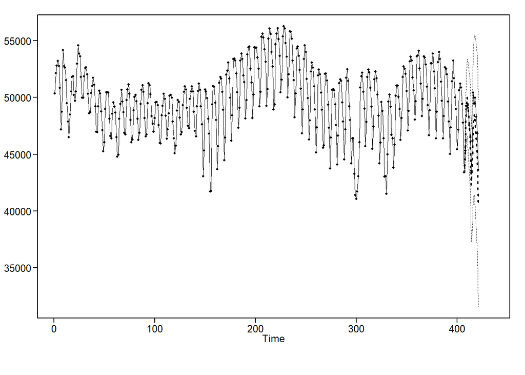

```r
model2_fore_short
```

```r
model2_ase_short = mean((txdata$inpatient_beds_used[(length(txdata$inpatient_beds_used)-13):length(txdata$inpatient_beds_used)]- model2_fore_short$f)^2)
model2_ase_short
```

```
## [1] 2575442
```

### ARIMA Model: Long 90-Day Forecast

```r
model2_fore_long = fore.aruma.wge(txdata$inpatient_beds_used, phi = final2$phi, theta = final2$theta, s = 7, d = 1,  limits = F, n.ahead = 90, lastn = T)
```

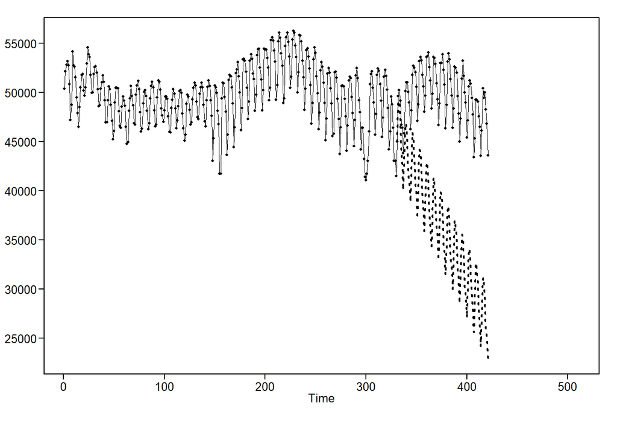

```r
model2_fore_long
```

```r
model2_ase_long = mean((txdata$inpatient_beds_used[(length(txdata$inpatient_beds_used)-89):length(txdata$inpatient_beds_used)]- model2_fore_long$f)^2)
model2_ase_long
```

```
## [1] 215922178
```

# MODEL 3

### With Vaccinations as a Leading Variable

The VAR model will add covid inpatient beds used and daily vaccinations. Vaccinations will be lagged to account for the time it takes to take effect. Assuming 21 days between shots and 2 weeks for maximum effectiveness, that’s ~35 days, so we will consider lags in that range. This may not be as helpful as it should be due to the first shot vs 2nd shot vs booster shot not being split out. Theoretically the 2nd shot would have the greatest negative correlation with inpatient beds after a 14-16 day lag.

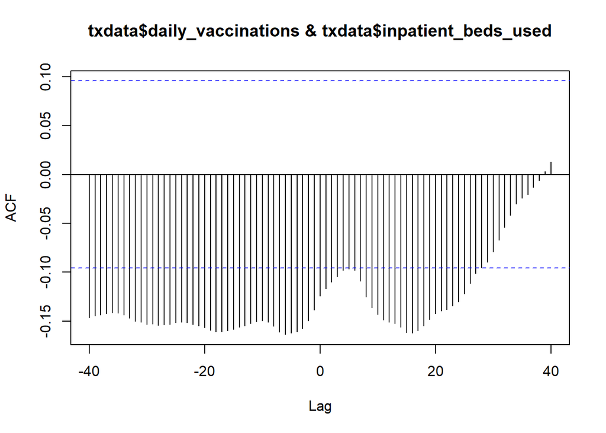

```r
#Check optimal lag value for daily vaccinations agains inpatient beds used.
ccf(txdata$daily_vaccinations, txdata$inpatient_beds_used, lag.max = 40)
```

```r
#Remove columns that won't be used.
var_lag_data = subset(txdata, select = c(3, 5, 8))
```

```r
#Lag vaccinations
vax_lag = dplyr::lead(var_lag_data$daily_vaccinations, 16)
var_lag_data$vax_lag = vax_lag
```

```r
#Remove original daily vaccination variable
var_lag_data = subset(var_lag_data, select = c(1, 2, 4))
```

```r
#for if the full set is needed without doing the train/test split
shortened_data = var_lag_data[1:405,]
```

### VAR Model: Short 14-Day Forecast

```r
#split the data. Because of lagged variable, we need to remove 16 days off the end of the set. Splitting 14 days before that for the forecast.
var_short_1 = var_lag_data[1:391,]
var_short_2 = var_lag_data[392:405,]
```

```r
#Pick AIC for covid beds -> (5,2)
covid_p = aic.wge(var_short_1$inpatient_beds_used_covid, p=0:8, q=0:2)
```

```r
#Pick AIC for vaccines -> (8,1)
vax_p = aic.wge(var_short_1$vax_lag, p=0:8, q=0:2)
```

Covid bed Estimates:

```r
covid_est = est.arma.wge(var_short_1$inpatient_beds_used_covid, p=covid_p$p, q=covid_p$q)
```

```
##
## Coefficients of Original polynomial:
## 2.5123 -2.0051 0.3221 0.3037 -0.1343
##
## Factor                 Roots                Abs Recip    System Freq
## 1-1.9754B+0.9776B^2    1.0103+-0.0465i      0.9887       0.0073
## 1-0.9377B+0.3427B^2    1.3682+-1.0228i      0.5854       0.1022
## 1+0.4008B             -2.4952               0.4008       0.5000
##
##
```

IP Covid Beds 14 Day Forecast:

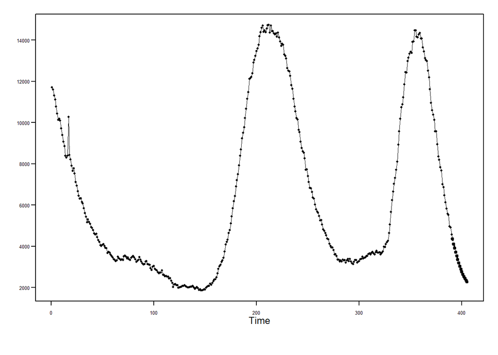

```r
fore.arma.wge(var_short_1$inpatient_beds_used_covid, phi = covid_est$phi, theta=covid_est$theta, n.ahead = 14, lastn = F, limits = F)
```

Vax Estimates:

```r
vax_est = est.arma.wge(var_short_1$vax_lag, p=vax_p$p, q=vax_p$q)
```

```
##
## Coefficients of Original polynomial:
## 1.0414 0.1111 -0.1180 0.0869 0.0026 -0.0593 -0.5220 0.4461
##
## Factor                 Roots                Abs Recip    System Freq
## 1-0.9869B              1.0133               0.9869       0.0000
## 1+0.9183B             -1.0890               0.9183       0.5000
## 1-0.4430B+0.8180B^2    0.2708+-1.0720i      0.9045       0.2106
## 1+1.1301B+0.7804B^2   -0.7241+-0.8701i      0.8834       0.3605
## 1-1.6599B+0.7712B^2    1.0762+-0.3721i      0.8782       0.0530
##
##
```

Vax 14 Day Forecast:

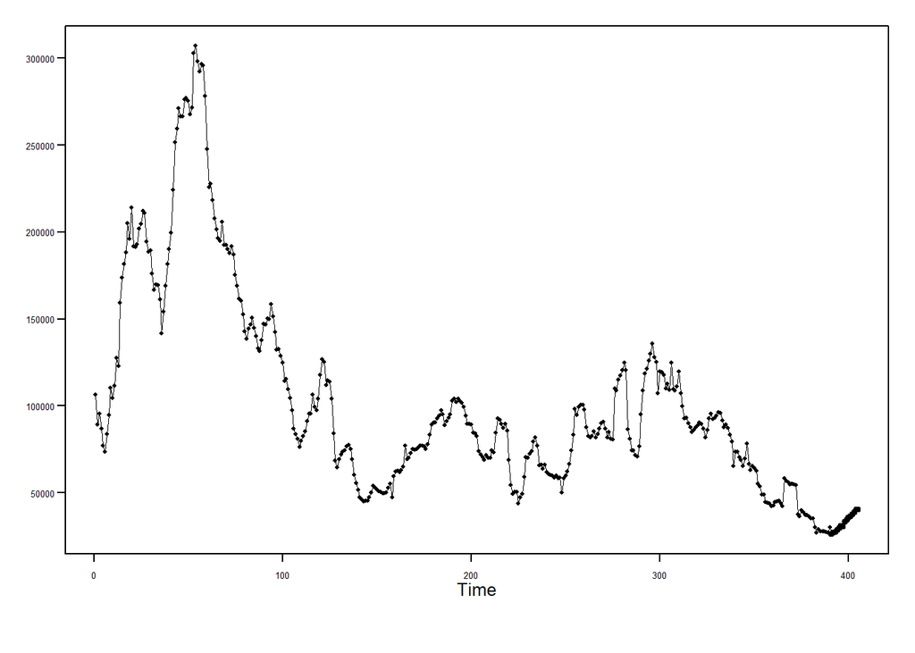

```r
fore.arma.wge(var_short_1$vax_lag, phi =vax_est$phi, theta=vax_est$theta, n.ahead = 14, lastn = F, limits = F)
```

```r
#Fitting w leading vax variable
#lowest AIC p = 9
VARselect(var_short_1)
```

```
## $selection
## AIC(n)  HQ(n)  SC(n) FPE(n)
##      9      9      8      9
##
## $criteria
##                                 1                         2
## AIC(n)                   44.20501                  43.58836
## HQ(n)                    44.25428                  43.67458
## SC(n)                    44.32920                  43.80568
## FPE(n) 15775915022250766336.00000 8515070990344603648.00000
##                                3                         4
## AIC(n)                  43.42047                  43.30032
## HQ(n)                   43.54365                  43.46045
## SC(n)                   43.73093                  43.70392
## FPE(n) 7199236200998903808.00000 6384478573901429760.00000
##                                5                         6
## AIC(n)                  43.05878                  42.72267
## HQ(n)                   43.25587                  42.95671
## SC(n)                   43.55551                  43.31254
## FPE(n) 5014827473877660672.00000 3583681258065491968.00000
##                                7                         8
## AIC(n)                  42.68721                  41.77623
## HQ(n)                   42.95821                  42.08418
## SC(n)                   43.37022                  42.55237
## FPE(n) 3459304821965475328.00000 1391341139066025472.00000
##                                9                        10
## AIC(n)                  41.69541                  41.71868
## HQ(n)                   42.04031                  42.10053
## SC(n)                   42.56469                  42.68110
## FPE(n) 1283609035786233088.00000 1314206421883624960.00000
```

```r
var_fit_short = VAR(var_short_1, p=9)
```

```r
preds_short = predict(var_fit_short, n.ahead = 14)
```

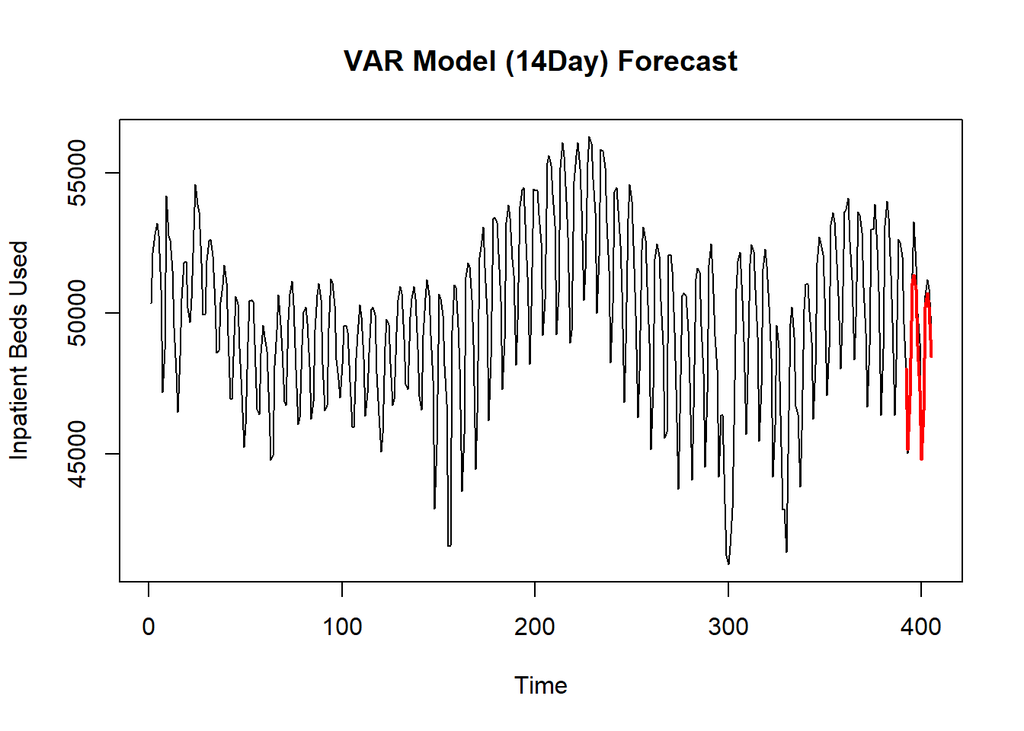

```r
plot(seq(1,405,1), shortened_data$inpatient_beds_used[1:405], type = "l", xlab = "Time", ylab = "Inpatient Beds Used", main = "VAR Model (14Day) Forecast")
points(seq(392,405,1), preds_short$fcst$inpatient_beds_used[1:14,1], type ="l", lwd = 2, col = "red")
```

```r
#Short 2 week forecast w leading var
#541239506
var_ase_short = mean((shortened_data$inpatient_beds_used[392:405] - preds_short$fcst$inpatient_beds_used)^2)
var_ase_short
```

```
## [1] 541239506
```

### VAR Model: Long 90-Day Forecast

```r
#split the data. Because of lagged variable, we need to remove 16 days off the end of the set. We are splitting 14 days before that for the forecast.
var_long_1 = var_lag_data[1:315,]
var_long_2 = var_lag_data[316:405,]
```

```r
#Pick AIC for covid beds -> (8,1)
covid_p = aic.wge(var_long_1$inpatient_beds_used_covid, p=0:8, q=0:2)
```

```r
#Pick AIC for vaccines -> (8,1)
vax_p = aic.wge(var_long_1$vax_lag, p=0:8, q=0:2)
```

Covid bed Estimates:

```r
covid_est = est.arma.wge(var_long_1$inpatient_beds_used_covid, p=covid_p$p, q=covid_p$q)
```

```
##
## Coefficients of Original polynomial:
## 1.3258 -0.2277 -0.0818 0.0847 0.0021 0.0370 0.0208 -0.1657
##
## Factor                 Roots                Abs Recip    System Freq
## 1-1.9902B+0.9915B^2    1.0036+-0.0360i      0.9957       0.0057
## 1-0.9569B+0.6706B^2    0.7135+-0.9910i      0.8189       0.1507
## 1+0.3451B+0.5153B^2   -0.3348+-1.3522i      0.7179       0.2886
## 1+1.2762B+0.4836B^2   -1.3196+-0.5715i      0.6954       0.4350
##
##
```

IP Covid Beds 90 Day Forecast:

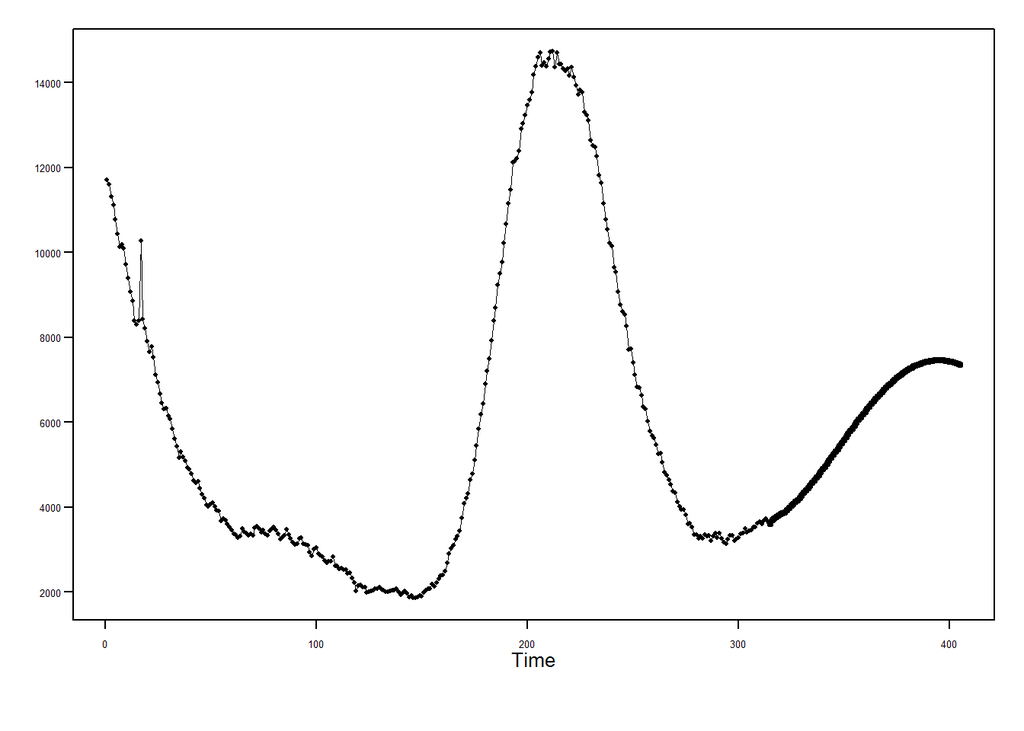

```r
fore.arma.wge(var_long_1$inpatient_beds_used_covid, phi = covid_est$phi, theta=covid_est$theta, n.ahead = 90, lastn = F, limits = F)
```

Vax Estimates:

```r
vax_est = est.arma.wge(var_long_1$vax_lag, p=vax_p$p, q=vax_p$q)
```

```
##
## Coefficients of Original polynomial:
## 1.0359 0.1287 -0.1399 0.0947 0.0002 -0.0550 -0.5277 0.4484
##
## Factor                 Roots                Abs Recip    System Freq
## 1-0.9825B              1.0178               0.9825       0.0000
## 1+0.9247B             -1.0814               0.9247       0.5000
## 1-0.4459B+0.8166B^2    0.2731+-1.0724i      0.9036       0.2103
## 1+1.1326B+0.7796B^2   -0.7264+-0.8690i      0.8829       0.3608
## 1-1.6647B+0.7752B^2    1.0737+-0.3703i      0.8805       0.0529
##
##
```

Vax 90 Day Forecast:

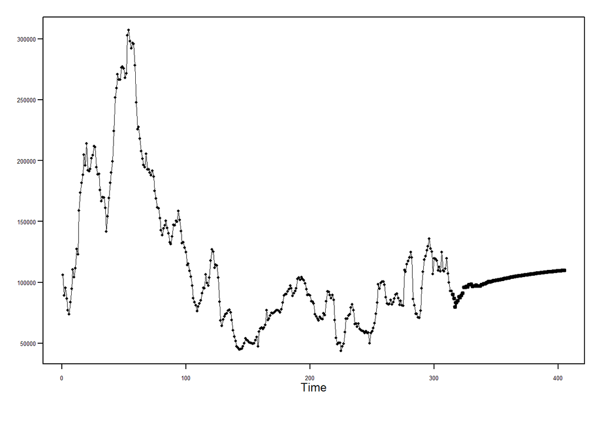

```r
fore.arma.wge(var_long_1$vax_lag, phi =vax_est$phi, theta=vax_est$theta, n.ahead = 90, lastn = F, limits = F)
```

```r
#lowest AIC p = 9
VARselect(var_long_1)
```

```
## $selection
## AIC(n)  HQ(n)  SC(n) FPE(n)
##      9      9      8      9
##
## $criteria
##                                 1                         2
## AIC(n)                   44.12719                  43.54630
## HQ(n)                    44.18574                  43.64875
## SC(n)                    44.27357                  43.80245
## FPE(n) 14594800400154996736.00000 8164452102629677056.00000
##                                3                         4
## AIC(n)                  43.45192                  43.36864
## HQ(n)                   43.59828                  43.55892
## SC(n)                   43.81785                  43.84435
## FPE(n) 7429482353391200256.00000 6836419493737953280.00000
##                                5                         6
## AIC(n)                  43.17537                  42.88418
## HQ(n)                   43.40955                  43.16227
## SC(n)                   43.76086                  43.57945
## FPE(n) 5635732532735941632.00000 4212809205503235072.00000
##                                7                         8
## AIC(n)                  42.85530                  41.96734
## HQ(n)                   43.17730                  42.33325
## SC(n)                   43.66035                  42.88217
## FPE(n) 4093980933715010560.00000 1685249043223557888.00000
##                                9                        10
## AIC(n)                  41.85884                  41.88631
## HQ(n)                   42.26866                  42.34004
## SC(n)                   42.88345                  43.02070
## FPE(n) 1512648069042641152.00000 1555639388344724992.00000
```

```r
var_fit_long = VAR(var_long_1, p=9)
```

```r
preds_long = predict(var_fit_long, n.ahead = 90)
```

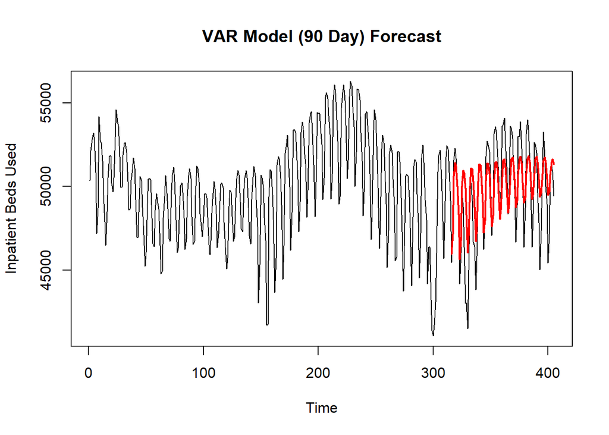

```r
plot(seq(1,405,1), shortened_data$inpatient_beds_used[1:405], type = "l", xlab = "Time", ylab = "Inpatient Beds Used", main = "VAR Model (90 Day) Forecast")
points(seq(316,405,1), preds_long$fcst$inpatient_beds_used[1:90,1], type ="l", lwd = 2, col = "red")
```

```r
#Long 90 Day Forecast w leading var
var_ase_long = mean((var_lag_data$inpatient_beds_used[316:405] - preds_long$fcst$inpatient_beds_used)^2)
var_ase_long
```

```
## [1] 527422879
```

# MODEL 4

### MLP Neural Network

```r
#Copy data set without lagged vaccine variable to not disrupt other models.
#The neural net will pick a lag as needed.
mlp_data = subset(txdata[1:405,],)
```

### MLP Model: Short 14-Day Forecast

```r
#create train and test splits
mlp_short_train = subset(mlp_data[1:391,],)
mlp_short_test = subset(mlp_data[392:405,],)
```

Build NN

```r
#Separete out the target variable into a train set univariate time series object
#Create a data frame made up of the different explanatory univariate time series objects

inp_univar = ts(mlp_short_train$inpatient_beds_used)

mlp_vars = data.frame(covid_univar = ts(mlp_data$inpatient_beds_used_covid), vax_univar = ts(mlp_data$daily_vaccinations))
```

```r
#Use median for the fit since there are enormous outlier predictions that heavily skew the mean.
mlp_fit_short = mlp(inp_univar, xreg = mlp_vars, comb = "median")
mlp_fit_short
```

```
## Single Layer Neural Network Specification ()
```

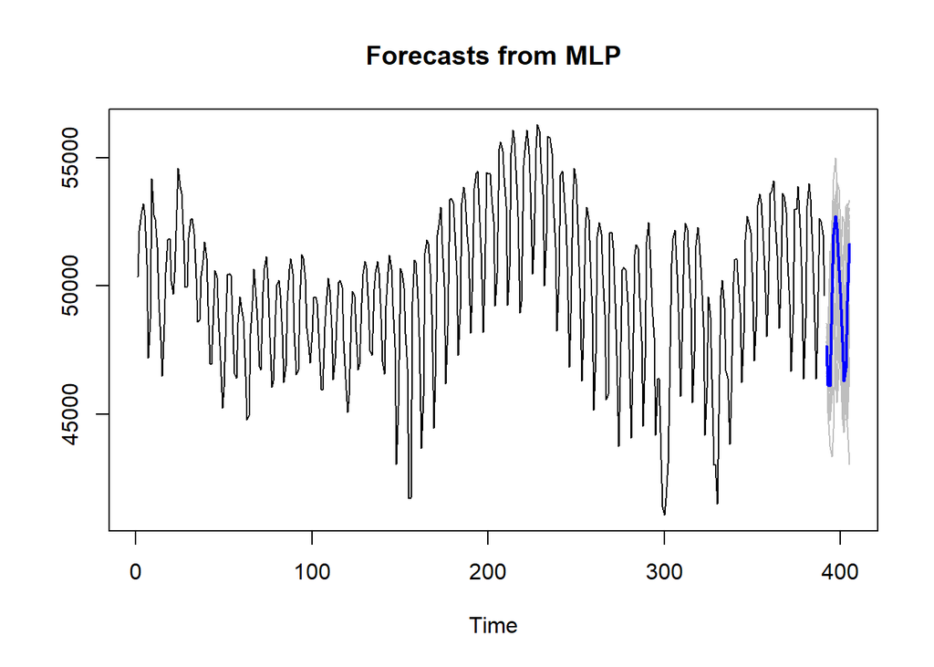

```r
mlp_fore_short = forecast(mlp_fit_short, h=14, xreg = mlp_vars)
plot(mlp_fore_short)
```

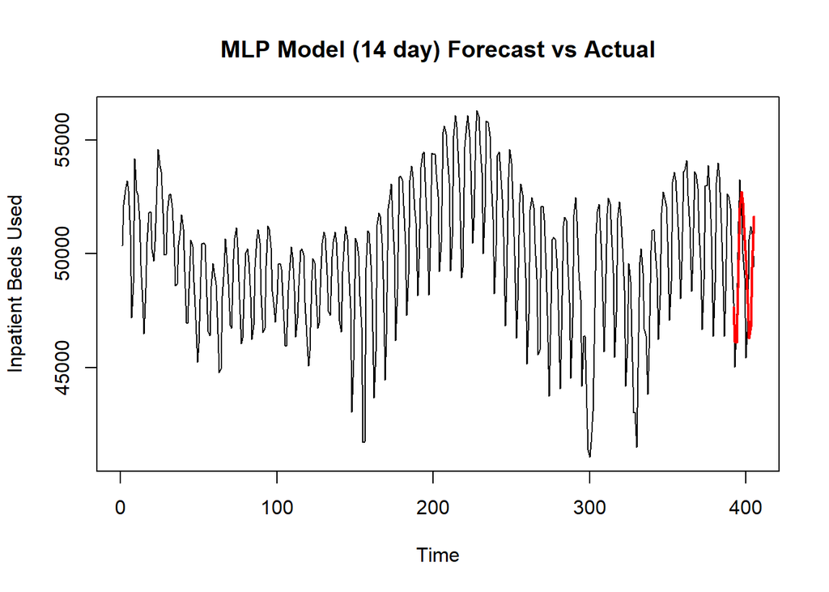

```r
plot(seq(1,405,1), shortened_data$inpatient_beds_used, type = "l", main = "MLP Model (14 day) Forecast vs Actual", xlab = "Time", ylab = "Inpatient Beds Used")
points(seq(392,405,1), mlp_fore_short$mean, type ="l", lwd = 2, col = "red")
```

```r
#4754072
mlp_ase_short = mean((mlp_short_test$inpatient_beds_used - mlp_fore_short$mean)^2)
mlp_ase_short
```

```
## [1] 5707198
```

### MLP Model: Long 90-Day Forecast

```r
#create train and test splits for 90 day horizon
mlp_long_train = subset(mlp_data[1:315,],)
mlp_long_test = subset(mlp_data[316:405,],)
```

```r
#Separate out the target variable into a train set univariate time series object
#Create a data frame made up of the different explanatory univariate time series objects

inp_univar_long = ts(mlp_long_train$inpatient_beds_used)

mlp_vars_long = data.frame(covid_univar = ts(mlp_data$inpatient_beds_used_covid), vax_univar = ts(mlp_data$daily_vaccinations))
```

```r
mlp_fit_long = mlp(inp_univar_long, xreg = mlp_vars_long, comb = "median")
mlp_fit_long
```

```
## Single Layer Neural Network Specification ()
```

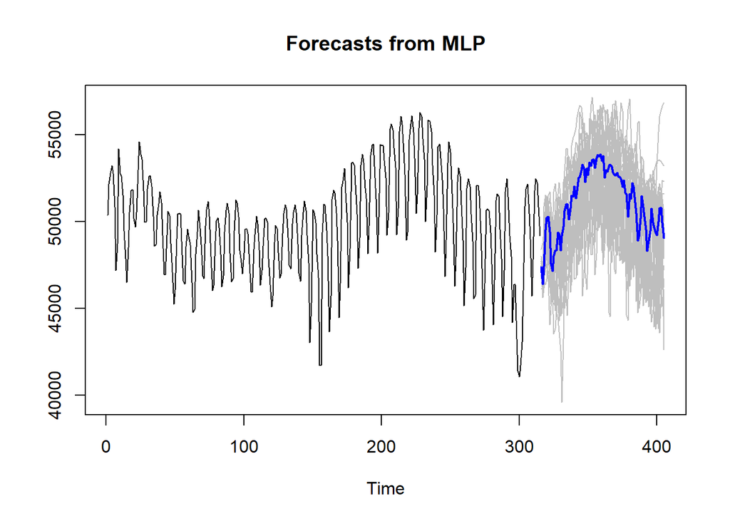

```r
mlp_fore_long = forecast(mlp_fit_long, h=90, xreg = mlp_vars_long)
plot(mlp_fore_long)
```

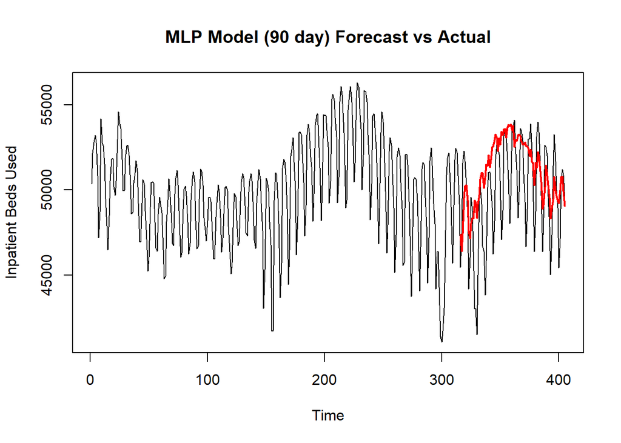

```r
plot(seq(1,405,1), shortened_data$inpatient_beds_used, type = "l", main = "MLP Model (90 day) Forecast vs Actual", xlab = "Time", ylab = "Inpatient Beds Used")
points(seq(316,405,1), mlp_fore_long$mean, type ="l", lwd = 2, col = "red")
```

```r
#8994974
mlp_ase = mean((mlp_long_test$inpatient_beds_used - mlp_fore_long$mean)^2)
mlp_ase
```

```
## [1] 8177363
```

# MODEL 5

### Ensemble Method

The VAR and MLP models (3 and 4 respectively) will be averaged together to build a well-rounded and more predictive model.

### Ensemble Model: Short 14-Day Forecast

```r
#Average the var model and MLP model predictions.
ensemble_short = (preds_short$fcst$inpatient_beds_used[,1] + mlp_fore_short$mean)/2
```

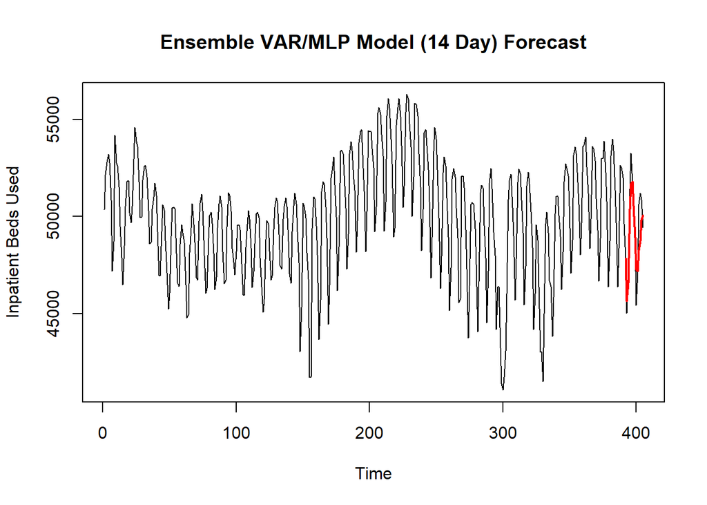

```r
plot(seq(1,405,1), shortened_data[,"inpatient_beds_used"], type = "l", xlab = "Time", ylab = "Inpatient Beds Used", main = "Ensemble VAR/MLP Model (14 Day) Forecast")
lines(seq(392,405,1), ensemble_short, type = "l", lwd = 2, col = "red")
```

```r
ensemble_ase_short = mean((shortened_data[392:405,"inpatient_beds_used"] - ensemble_short)^2)
ensemble_ase_short
```

```
## [1] 1517742
```

### Ensemble Model: Long 90-Day Forecast

```r
#Average the var model and MLP model predictions.
ensemble_long = (preds_long$fcst$inpatient_beds_used[,1] + mlp_fore_long$mean)/2
```

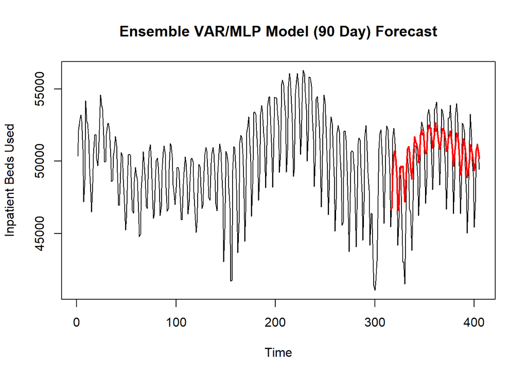

```r
plot(seq(1,405,1), shortened_data[,"inpatient_beds_used"], type = "l", xlab = "Time", ylab = "Inpatient Beds Used", main = "Ensemble VAR/MLP Model (90 Day) Forecast")
lines(seq(316,405,1), ensemble_long, type = "l", lwd = 2, col = "red")
```

```r
ensemble_ase_long = mean((shortened_data[316:405,"inpatient_beds_used"] - ensemble_long)^2)
ensemble_ase_long
```

```
## [1] 4684430
```